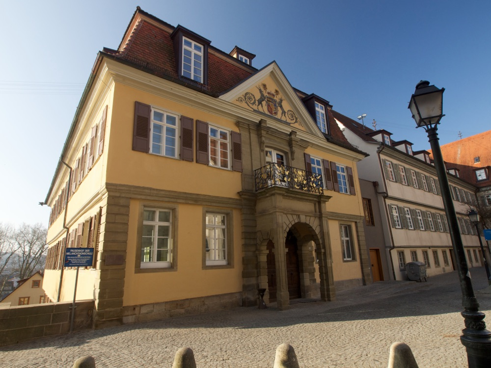

## Professionalität von Lehrer:innen

Teil 2 der Einführung in das Studium der Bildungswissenschaften

Prof. Dr. Samuel Merk

Wintersemester 2026/27

Wirtschafts- und Sozialwissenschaftliche Fakultät · Institut für Erziehungswissenschaft

## In diesem Teil

- Charakteristika des Lehrer:innenberufs
- Profession - Professionalität - Professionalisierung
- Struktur- und kompetenztheoretischer Ansatz der Professionalität von Lehrer:innen
- Einblicke in Forschungsergebnisse

## Charakteristika des Unterrichts

Nach Doyle (1986) ist Unterricht durch die folgenden Eigenschaften in seiner Besonderheit charakterisiert (Cramer, 2025):

| Multidimensionalität | Viele, sehr verschiedene Ereignisse finden aufgrund der vielen Personen im Klassenraum statt. |
| --- | --- |
| Simultanität | Viele Dinge geschehen gleichzeitig im Unterricht. |
| Unmittelbarkeit | Aufgrund des schnellen Ablaufes von Ereignissen im Unterricht ist ein unmittelbares Lehrer:innenhandeln gefordert, welches eine Reflexion erschwert. |
| Unvorhersehbarkeit | Unterricht kann nicht sicher vorhergesehen und nur beschränkt geplant werden. |
| Öffentlichkeit | Interaktionen finden in einem „öffentlichen“ Raum statt und gehen dabei über den Kreis der direkt Beteiligten hinaus. |
| Historizität | Gegenwärtiges Handeln im Klassenzimmer hat immer Wurzeln in der Vergangenheit und Auswirkungen in die Zukunft. |
| Intransparenz | Lehrperson und Schüler:innen können gegenseitig nur erahnen, was im jeweils anderen vor sich geht und nur über (störanfällige) Kommunikation aufeinander Einfluss nehmen. |
| Informalität | Unterrichten ist situativ und nur in geringem Ausmaß standardisierbar oder reglementierbar. |

### Charakteristika des Unterrichts $\overset{?}{\Rightarrow}$ Anforderungen an LuL

> Welche Anforderungen an die Qualitäten von Lehrkräften lassen sich aus diesen Charakteristika ableiten?

> Formulieren Sie Eigenschaften von Lehrkräften, die diese Anforderungen notwendig machen unter https://bab.si/biwi-merk-2627 und »voten« Sie die Vorschläge Ihrer Kommiliton:innen.

# Anforderungen an Lehrer:innen

## Anforderungen an Lehrer:innen

Diese Charakteristika (Doyle, 1986) des Kerngeschäfts Unterricht (Tenorth, 2006) stehen teilweise im Widerspruch zu personalistischen und praktizistischen Metaphern des Lehrer:innenberufs, nach denen professionelle Lehrer:innen »gute, erfahrene Handwerker«, bzw. »begnadete Erzieher« (Terhart, 2019) sind:

[figure not shown]

## Begriffe

#### Profession

Aus berufssoziologischer Perspektive wird eine Profession einerseits als besonderer, herausgehobener Beruf aufgefasst (Freidson, 2001), andererseits als Beruf, der durch Risiken und Ungewissheit in der Ausübung durch Professionelle (Berufsinhabende) charakterisiert ist (Stichweh, 1994).

#### Professionalität

Professionalität beschreibt die »*spezifische Qualität des beruflichen Handelns*« (Horn, 2016, S. 156).

## Begriffe

#### Professionalisierung

»*Der Begriff Professionalisierung wird in zwei Absichten verwendet. Bezieht er sich auf die Professionen selbst, so meint er in historischer Absicht den Transformationsprozess eines gewöhnlichen Berufes hin zur Profession (Professionwerdung); wird er hingegen auf die Professionellen bezogen, meint er das individuelle Hervorbringen von Professionalität (Professionellwerden). Heute wird unter Professionalisierung überwiegend die (individuelle) Entwicklung von Professionalität verstanden.*« (Cramer, 2025)

# 1. Ansatz: Expertiseforschung

## Expertiseforschung

### Liveexperiment

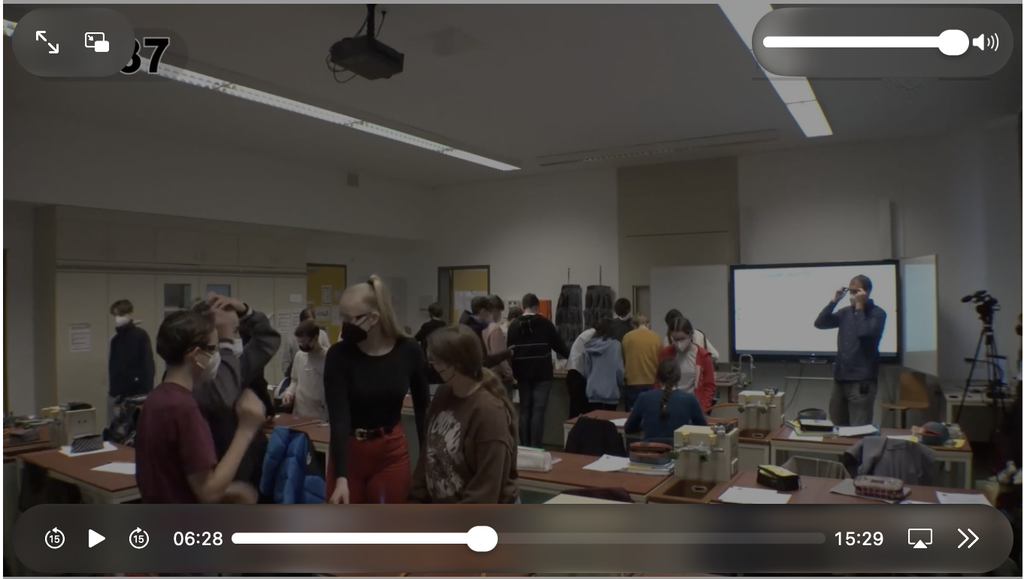

> Beschreiben Sie das beobachtete Unterrichtsgeschehen *charakterisierend* unter https://bab.si/biwi-merk-2627. Verwenden Sie dazu mindestens zwei vollständige Sätze 😇. Ihre Ergebnisse werden später aufgegriffen.

## Expertiseforschung

[figure not shown]

Abbildung 1

[figure not shown]

Abbildung 2

## Studien zur Schachexpertise ✨

In berühmten Experimenten von Adriaan de Groot (Groot, 1965), William Chase und Herbert Simon (Chase & Simon, 1973b, 1973a) wurde die Expertise von Schachspieler:innen untersucht.

### Der Versuchsaufbau

- **Probandengruppen:** Verglichen wurden drei Spieler unterschiedlicher Kompetenzstufen – ein **Schachmeister** (unter den Top 25 der USA), ein **guter Vereinsspieler** und ein **Anfänger**.
- **Darbietung:** Den Probanden wurde ein Schachbrett mit einer Stellung aus einer echten Partie (Mittel- oder Endspiel) für genau **5 Sekunden** gezeigt.
- **Reproduktion:** Direkt im Anschluss mussten die Spieler versuchen, die gesehene Stellung aus dem Gedächtnis auf einem zweiten, leeren Schachbrett aufzustellen.
- **Wiederholung & Kriterium:** Nach jedem Versuch durften die Probanden erneut für 5 Sekunden auf die Vorlage blicken. Dieser Vorgang wurde so lange wiederholt, bis die Position korrekt reproduziert war. Als Gütekriterium galt die Anzahl der benötigten 5-Sekunden-Betrachtungen.
- **Testmaterial:** Das Experiment wurde mit **20 echten Spielstellungen** durchgeführt. Ergänzend wurden **8 Zufallsaufstellungen** mit einer identischen Anzahl an Figuren einbezogen, bei denen die Figuren völlig beliebig auf dem Brett verteilt waren.

### Die Ergebnisse

- **Bei echten Schachstellungen:**
  - Der **Schachmeister** konnte bereits nach dem ersten 5-sekündigen Hinsehen durchschnittlich **16 Figuren** korrekt platzieren und benötigte insgesamt nur 3 bis 4 Betrachtungen für eine fehlerfreie Rekonstruktion.
  - Der **gute Spieler** platzierte beim ersten Blick durchschnittlich **8 Figuren** (und benötigte 1–2 Betrachtungen mehr als der Meister).
  - Der **Anfänger** schaffte beim ersten Mal nur **4 Figuren** und brauchte bis zu 14 Betrachtungen.
- **Bei Zufallsaufstellungen:**
  - Sobald die Figuren zufällig verteilt waren und keine sinnvolle Schachstruktur bildeten, verschwanden die Leistungsunterschiede vollständig; der Meister schnitt nicht besser ab als der Anfänger.

## Studien zur Physikexpertise ✨

### Der Versuchsaufbau

- **Probandengruppen:** Chi et al (1981) verglichen **Physik-Experten** (Doktoranden oder Hochschullehrer der Physik) und **Anfänger** (Studenten nach einem einführenden Kurs in Mechanik).
- **Aufgabenstellung:** Den Probanden wurden Textaufgaben aus der Mechanik oder Thermodynamik vorgelegt, die sie in einem Experiment frei nach Ähnlichkeit sortieren sollten. In weiteren Experimenten wurden Verbalprotokolle des Lauten Denkens beim eigentlichen Problemlösen erhoben.

### Die Ergebnisse

- **Anfänger** sortierten die Textaufgaben nach **Oberflächenmerkmalen**, also nach den konkret genannten physischen Objekten (z. B. schiefe Ebene, Rollen, Seile). Beim Lösen dachten sie vom Ziel her („Rückwärts-Arbeiten”) und ersetzten Variablen Schritt für Schritt.
- **Experten** gruppierten die Aufgaben nach **Tiefenstrukturen bzw. physikalischen Prinzipien** (z. B. Erhaltung der Energie, 2. Newtonsches Gesetz). Sie sahen physikalische Objekte sofort im Kontext von Lösungsprozeduren und mathematischen Gleichungen. Beim Problemlösen arbeiteten sie datengeleitet von den gegebenen Werten aus („Vorwärts-Arbeiten”) und setzten Zahlen direkt in das passende Prinzip ein.

### Theoretische Erklärung

Experten besitzen kein generell überlegenes Gedächtnis, sondern verfügen über ein Wissen, das um **abstrakte physikalische Gesetze** herum kohärent organisiert ist. Die Fachstruktur und das funktionale Problemverständnis verschmelzen bei ihnen, was ein unmittelbares, intuitives Erkennen des Problemtyps ermöglicht.

## Studien zur Lehrer:innenexpertise ✨

### Der Versuchsaufbau:

- **Probandengruppen:** Berliner und Mitarbeiter (1992) verglichen drei Gruppen: **Experten** (Lehrkräfte mit mindestens 5 Jahren Berufserfahrung und hervorragenden Beurteilungen), **Anfänger** (Lehrkräfte im ersten Berufsjahr) und **Anwärter** (Ingenieure/Naturwissenschaftler ohne pädagogische Ausbildung).
- **Darbietung & Simulation:**
  1. *Wahrnehmung von Unterrichtsszenen:* Dias von Unterrichtssituationen wurden kurz für 1 bis 3 Sekunden gezeigt oder als Bildserie vorgeführt.
  2. *Verarbeitung von Schülerinformationen:* Die Probanden sollten anhand von Schülerakten, Noten, Tests und Lehrbüchern in 40 Minuten die Übernahme einer fremden Klasse vorbereiten; anschließend folgte ein Gedächtnistest zu Schülerdetails.

### Die Ergebnisse:

- **Wahrnehmung von Unterrichtsdias:**
  - **Anfänger und Anwärter** beschrieben visuelle **Oberflächendetails** wie Haarfarbe, Geschlecht, Raumausstattung oder die genaue Sitzordnung.
  - **Experten** nutzten **abstraktere pädagogische Begriffe** (sahen z. B. „Gruppenarbeit” statt bloß „miteinander redender Schüler”). Sie erkannten sofort typische vs. untypische Unterrichtsstrukturen und fokussierten sich auf die Schüleraktivitäten und den Unterrichtsfluss.
- **Verarbeitung schriftlicher Schülerdaten:**
  - **Anfänger und Anwärter** behielten nach der Vorbereitung sehr viele **demographische Fakten und Einzeldetails** über Schüler im Gedächtnis.
  - **Experten** schnitten beim Behalten isolierter demographischer Schülerdetails schlecht ab. Sie filterten unwichtige Fakten und verschmolzen die Einzeldaten zu einem handlungsrelevanten **Gesamtbild der Klasse („Kollektiver Schüler”)**. Zudem richteten sie ihre Aufmerksamkeit stark auf den Stand der Stoffentwicklung und fachdidaktische Techniken.

### Theoretische Erklärung:

Berliner erklärt die Befunde durch Unterschiede in der **kategorialen Wahrnehmung**. Experten verfügen im Langzeitgedächtnis über **Schemata und Prototypen typischer Unterrichtsereignisse (»Aktivitätsszenarien«)**. Begriffe über Schüler sind bei Experten eng an situative Handlungskontexte gebunden (Erfahrungs- und Situationsbezug), wodurch sie relevante von irrelevanten Informationen für die Erfordernisse der Klassenführung trennen können.

## Einschätzung

> Angenommen es gibt Expert:innen Noviz:innen im Lehrer:innenberuf. Wie stark unterscheiden sich die Leistungen deren Schüler:innen? Bearbeiten Sie die folgende Einschätzung

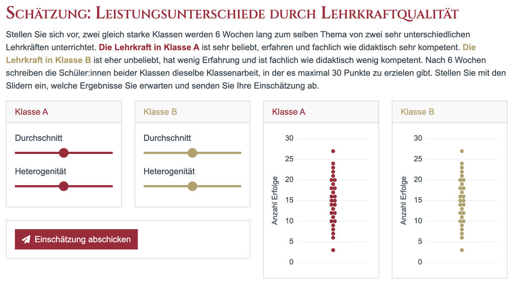

## Ihre Ergebnisse

[figure not shown]

Abbildung 3

> Welche Kritik an der internen & externen Validität der klassischen Teacher Value-Added Studien können Sie sich vorstellen? Formulieren Sie Ihre Ideen unter https://bab.si/biwi-merk-2627 (🙏🏽🙏🏽 biddebidde in ganzen Sätzen 😳) und »voten« Sie die Vorschläge Ihrer Kommiliton:innen.

# 2. Ansatz: Topologien von Wissen/Kompetenzen

## Topologische Ansätze

Während Teacher Value-Added Studien Lehrer:inneneffekte als Blackbox betrachten, analysieren topologische Ansätze die strukturellen Zusammenhänge zwischen Lehrer:innen**merkmalen** und Unterrichtserfolg. Diese Merkmale werden dann entlang psychologischer Theorien (Baumert & Kunter, 2006; Shulman, 1986). Weil angenommen wird, dass die (topologisierten) Merkmale bei höherer Ausprägung die erfolgreiche Bewältigung charakteristischer Anforderungen der Profession wahrscheinlicher machen, werden die topologischen Ansätze auch als kompetenztheoretische Ansätze bezeichnet.

[figure not shown]

Abbildung 4: Topologie der Aspekte von Lehrer:innenprofessionalität (Baumert & Kunter, 2006)

## Kompetenztheoretischer Ansatz

### Professionswissen: Illustration

- Fachwissen: Wissen über die fachwissenschaftlichen Grundlagen des Unterrichtsfaches (»*Warum ist 0,9999… = 1*«, »*Was sind Plosivlaute*«)
- Fachdidaktisches Wissen: Wissen über die Vermittlung des Unterrichtsfaches (»*Welche Fehlkonzepte von Beweisen liegen typischerweise vor?*«, »*Welche Rechtschreibstrategien sind wofür effektiv?*«)
- Pädagogisches Wissen: Wissen über die Vermittlung von Unterrichtsinhalten und die Gestaltung von Lernprozessen (»*Wie kann ich eine Klasse motivieren?*«, »*Wie kann ich mit Störungen umgehen?*«)

> Schätzen Sie die Relevanz der Komponenten unter https://bab.si/biwi-merk-2627 ein.

## Kompetenztheoretischer Ansatz

### Motivationale Orientierungen: Empirische Befunde

- Annahme: Der Lehrberuf erfordert dauerhaft Konzentration, Umgang mit Misserfolgen und die Bereitschaft zu langfristigem Engagement – neben kognitiven Fähigkeiten braucht es also auch motivationale Bereitschaft
- Häufig untersuchte Konstrukte: Studien- und Berufswahlmotive, Enthusiasmus bzw. intrinsische Motivation beim Unterrichten, Zielorientierungen
- Kaum Studien zum Zusammenhang mit Lernzuwächsen; Ausnahme **COACTIV**: positiver Effekt des Enthusiasmus für das Unterrichten (nicht des Fachenthusiasmus) auf den Lernzuwachs
- Schüler:innen enthusiastischer bzw. intrinsisch motivierter Lehrkräfte zeigen höhere Motivation und mehr Interesse
- Insgesamt: Bedeutsamkeit plausibel, Zusammenhang mit Lernzuwächsen aber nicht eindeutig geklärt (Neugebauer, 2013)

## Leuchtturmprojekte ✨

### Topologischer/Kompetenztheoretischer Forschung

#### [COACTIV](https://web.archive.org/web/20130114220538/http://www.mpib-berlin.mpg.de/coactiv/index.html)

- Ergänzung zur PISA-Studie 2003/04: Mathematiklehrkräfte der untersuchten Klassen befragt, getestet und um die Abgabe von Unterrichtsmaterialien gebeten
- Kompetenzfacetten: Fachwissen, fachdidaktisches und pädagogisches Wissen; zusätzlich Überzeugungen, Motivation, Selbstregulation
- Verknüpfung mit der Schüler:innenkompetenz im Längsschnitt

#### [TEDS-M](https://www.teds-unterricht.uni-hamburg.de/weitere-teds-studien/teds-m.html)

- Studie (2006–2009) zur Wirksamkeit der Mathematiklehrer:innenausbildung im internationalen Vergleich
- Angehende Lehrkräfte für Primarstufe und Sekundarstufe I im letzten Ausbildungsjahr
- Kern: mathematisches, mathematikdidaktisches und erziehungswissenschaftliches Wissen sowie Überzeugungen
- Internationaler Vergleich, für Deutschland mit repräsentativer Stichprobe

#### [BilWiss](https://pd.reha.tu-dortmund.de/forschung/projekte/abgeschlossene-projekte/bilwiss/)

- Forschungsprogramm 2009–2019
- Fokus: Bildungswissenschaftliches Wissen
- Delphi-Studie mit 49 Expert:innen: 104 relevante Themen als Basis eines Wissenstests
- Hauptstudie mit 3.118 Lehramtsabsolvent:innen und Längsschnitt

# 3. Ansatz: Strukturtheorie

## Strukturtheoretischer Ansatz

Der Strukturtheoretische Ansatz ist stark von qualitativ forschenden Soziolog:innen geprägt und fokussiert Rollenerwartungen und soziale Gefüge.

[figure not shown]

Abbildung 5: Sachantinomie als Beispiel

#### Antinomien des Lehrpersonenhandelns (Beispiele)

- Person des Schülers versus Anspruch der Sache (siehe Abbildung 5)
- Nähe versus Distanz zum Schüler
- Autonomie versus Heteronomie
- Organisation und Interaktion

> Professionalität heißt hier, antinomische Spannungen wahrzunehmen, zu reflektieren und im eigenen Handeln in Balance zu bringen

## Leuchtturmprojekte ✨

### Strukturtheoretischer Forschung

#### [Distinktion im Gymnasialen](https://www.zsb.uni-halle.de/forschungsprojekte/2503071_2617909/distinktion_im_gymnasialen/?lang=de)

- DFG-Teilprojekt (2011–2019) der Forschergruppe „Mechanismen der Elitebildung“ am ZSB Halle, Leitung Werner Helsper
- Frage: Wie bildet sich Habitus an exklusiven höheren Schulen?
- Fokus: Gymnasien als Feld horizontaler Distinktion und Hierarchisierung

#### [Disziplinierung – Zur Herstellung und Aufrechterhaltung unterrichtlicher Ordnung](https://www.uni-flensburg.de/erziehungswissenschaften/wer-wir-sind/personen-2/rademacher-sandra-prof-dr/disziplinierung-zur-herstellung-und-aufrechterhaltung-unterrichtlicher-ordnung)

- Projekt von Sandra Rademacher (Europa-Universität Flensburg), Laufzeit 2011–2016
- Verbindet professionalisierungs- mit sozialisationstheoretischen Fragen
- Empirische Betrachtung des Professionalisierungsmodells zur Disziplinierung
- Datenbasis: Beobachtungsprotokolle und Transkripte aus Grund- und weiterführenden Schulen, Klassen 1 bis 12

## Literatur

Baumert, J., & Kunter, M. (2006). Stichwort: Professionelle Kompetenz von Lehrkräften. *Zeitschrift für Erziehungswissenschaft*, *9*(4), 469–520. https://doi.org/10.1007/s11618-006-0165-2

Baumert, J., & Kunter, M. (2011). Professionelle Kompetenz von Lehrkräften. In M. Kunter, J. Baumert, W. Blum, U. Klusmann, S. Krauss, & M. Neubrand (Hrsg.), *Zeitschrift für Erziehungswissenschaft* (Bd. 9). Waxmann. https://doi.org/10.1007/s11618-006-0165-2

Berliner, D. C. (1992). The Nature of Expertise in Teaching. In F. K. Oser, A. Dick, & J.-L. Patry (Hrsg.), *Effective and Responsible Teaching: The New Synthesis* (S. 227–248). Jossey-Bass.

Bromme, R., & Haag, L. (2008). Forschung Zur Lehrerpersönlichkeit. [Online; Gedruckt]. In W. Helsper & J. Böhme (Hrsg.), *Handbuch Der Schulforschung* (S. 803–819). VS Verl. für Sozialwissenschaften.

Chase, W. G., & Simon, H. A. (1973a). Perception in Chess. *Cognitive Psychology*, *4*, 55–81. https://doi.org/10.1016/0010-0285(73)90004-2

Chase, W. G., & Simon, H. A. (1973b). The Mind’s Eye in Chess. In W. G. Chase (Hrsg.), *Visual Information Processing* (S. 215–281). Academic Press.

Chi, M. T. H., Feltovich, P. J., & Glaser, R. (1981). Categorization and Representation of Physics Problems by Experts and Novices. *Cognitive Science*, *5*(2), 121–152. https://doi.org/10.1207/s15516709cog0502_2

Cramer, C. (2025). *Professionalität von Lehrpersonen. Bildungswissenschaften I, Sitzung 6* [Vorlesungsfolien]. Vorlesung im Wintersemester 2025/2026 (Herbstsemester 2025); Universität Konstanz und Pädagogische Hochschule Thurgau.

Doyle, W. (1986). Classroom Organization and Management. In M. C. Wittrock (Hrsg.), *Handbook of Research on Teaching* (S. 392–431). Macmillan.

Dubberke, T., Kunter, M., McElvany, N., Brunner, M., & Baumert, J. (2008). Lerntheoretische Überzeugungen von Mathematiklehrkräften. Einflüsse auf die Unterrichtsgestaltung und den Lernerfolg von Schülerinnen und Schülern. *Zeitschrift für Pädagogische Psychologie*, *22*(3-4), 193–206. https://doi.org/10.1024/1010-0652.22.34.193

Freidson, E. (2001). *Professionalism: The Third Logic* (S. 240). University of Chicago Press.

Groot, A. D. de. (1965). *Thought and Choice in Chess*. Mouton.

Hanushek, E. (1971). Teacher Characteristics and Gains in Student Achievement: Estimation Using Micro Data. *The American Economic Review*, *61*(2), 280–288.

Horn, K.-P. (2016). Profession, Professionalisierung, Professionalität, Professionalismus – Historische und systematische Anmerkungen am Beispiel der deutschen Lehrerausbildung. *Zeitschrift für Pädagogik und Theologie*, *68*(2), 153–164. https://doi.org/10.1515/zpt-2016-0017

Neugebauer, M. (2013). *Kommt es auf den Lehrer an? – Empirische Studien zur Selektion in das Lehramt und zu Lehrereffekten bei der Entstehung ungleicher Bildungschancen* [Inauguraldissertation]. Universität Mannheim, Fakultät für Sozialwissenschaften.

Shulman, L. S. (1986). Those Who Understand: Knowledge Growth in Teaching. *Educational Researcher*, *15*(2), 4–14. https://doi.org/10.3102/0013189X015002004

Stichweh, R. (1994). *Wissenschaft, Universität, Professionen. Soziologische Analysen*. Suhrkamp.

Tenorth, H.-E. (2006). Professionalität Im Lehrerberuf. Ratlosigkeit Der Theorie, Gelingende Praxis. [Online; Gedruckt]. *Zeitschrift für Erziehungswissenschaft*, *9*(4), 580–597.

Terhart, E. (2019). *Didaktik: eine Einführung* (1. Auflage). Reclam Verlag.

Voss, T., Kleickmann, T., Kunter, M., & Hachfeld, A. (2011). Überzeugungen von Mathematiklehrkräften. In M. Kunter, J. Baumert, W. Blum, U. Klusmann, S. Krauss, & M. Neubrand (Hrsg.), *Professionelle Kompetenz von Lehrkräften* (S. 235–257). Waxmann.

Weber, A., Weltle, D., & Lederer, P. (2004). Frühinvalidität im Lehrerberuf: Sozial- und arbeitsmedizinische Aspekte. *Deutsches Ärzteblatt*, *101*, 850–859.